# 2.High transcript biased gene sets

Set a cut-off for the minimum number of times a category must appear in the 100 tests.

Generate lists of mouse genes by number of transcripts. In the mouse genome, most genes have only one transcript, but some have many more.  
Do sets of genes with high numbers of transcripts produce significant results in GO overrepresentation analysis?

### Pre-processing of data on cluster

Import the genfo file as described in 0.Generating biased gene lists : pre-processing.

This can be used to plot the distribution of the number of transcripts per gene in the Mus_musculus.GRCm38.94 genome.

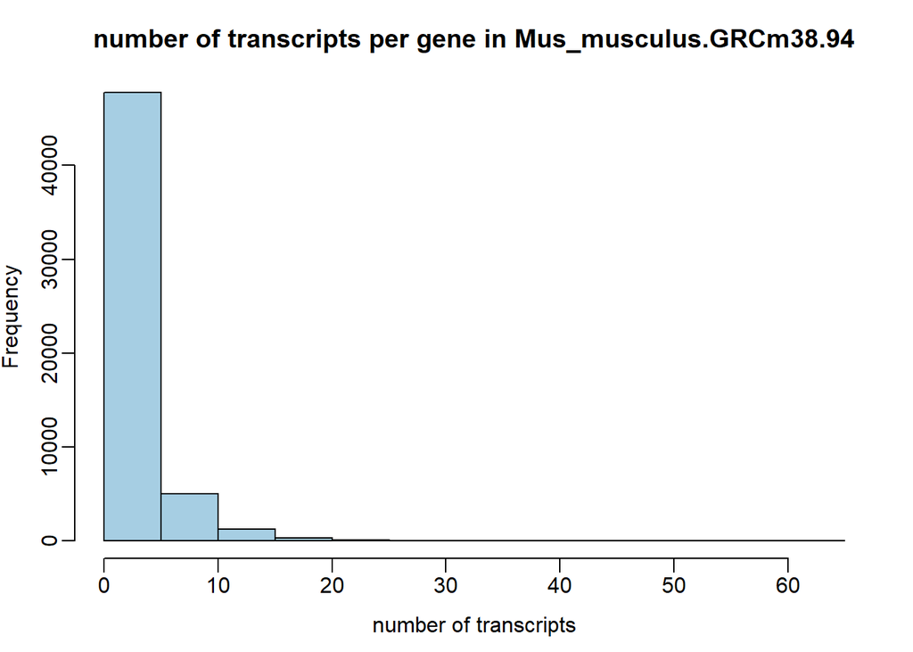

As expected, most genes have very low numbers of transcripts, so we don’t get much information from this plot. We can look at the information in a table format to get actual numbers.

```
##
##     1     2     3     4     5     6     7     8     9    10    11    12
## 34054  5813  3405  2517  1980  1548  1217   946   711   574   387   314
##    13    14    15    16    17    18    19    20    21    22    23    24
##   239   180   124    92    67    67    37    39    25    14    15    10
##    25    26    27    28    29    30    31    32    33    34    35    36
##    17    11     6     7     1     4     7     1     1     3     2     2
##    37    38    39    41    46    47    48    58    62
##     1     1     1     1     1     1     1     1     1
```

63% of genes only have one transcript. 11% of genes have two transcripts. I’m not interested in these so I’ll replot the data and see how it looks without these values. Above 30 there are only a handful of genes so these can be removed from the plot to see it better.

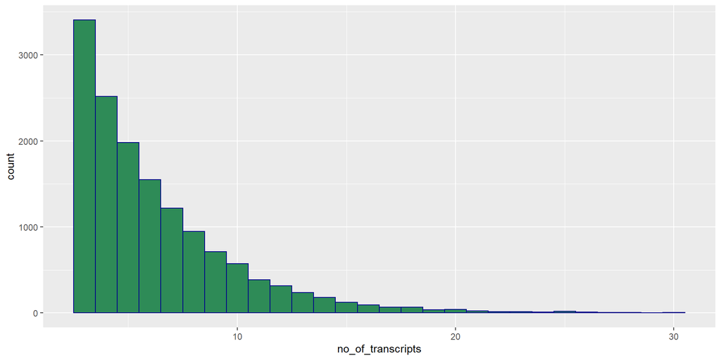

#### Generating thresholds

Originally, I selected arbitrary thresholds of minimum 10, 15 and 20 transcripts per gene. These seemed like reasonable numbers to choose and plenty of functional categories were identified in the overrepresentation tests.

It is not ideal having hardcoded values when it comes to generating further sets of genes. Selecting thresholds dependent on the distribution of the data is a more robust method for applying to different species and future versions of this genome.

|  | transcript_thresholds | probabilities | gene_counts |
| --- | --- | --- | --- |
| 90% | 6 | 0.90 | 6677 |
| 95% | 9 | 0.95 | 2966 |
| 99% | 15 | 0.99 | 561 |

It worked nicely for the gene lengths to plot out the numbers on graphs but the distribution here doesn’t plot quite so well.

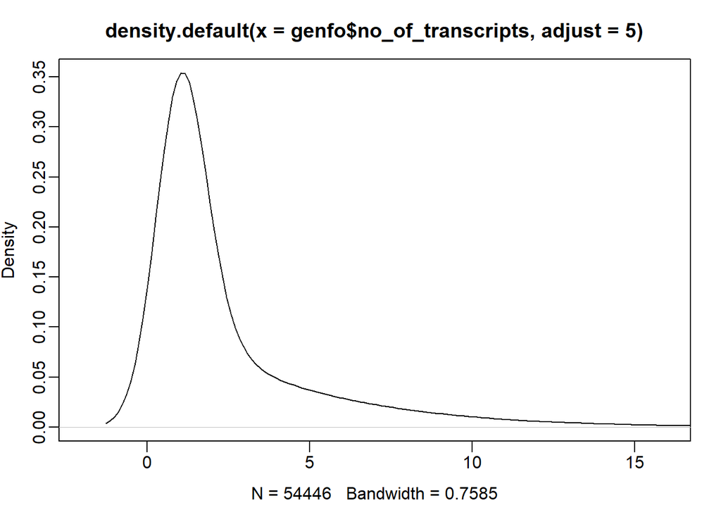

### Generating the biased gene lists within R

Check they all look right

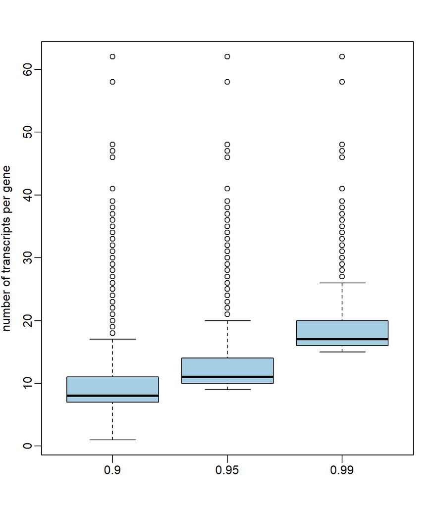

### GO overrepresentation analysis

Run the gene lists through a GO overrepresentation analysis.

We don’t want to run the analysis each time the document is knitted as it takes too long. The code was run once and the data saved as an .rda object that can be quickly loaded in to the R session.

See how many significant categories were returned.

The number of gene sets that returned significant results from the GO overrepresentation analysis

```
##  0.9 0.95 0.99
##  100  100  100
```

The bean plots show the number of categories returned from each gene list. The null results have been removed.

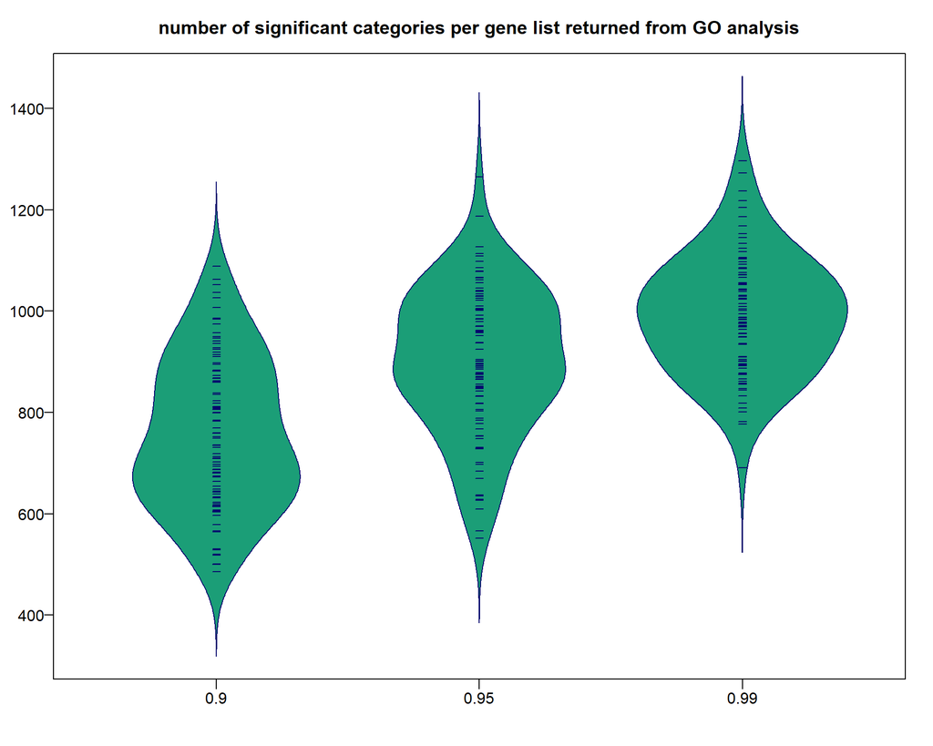

Plot how many times a category appeared.

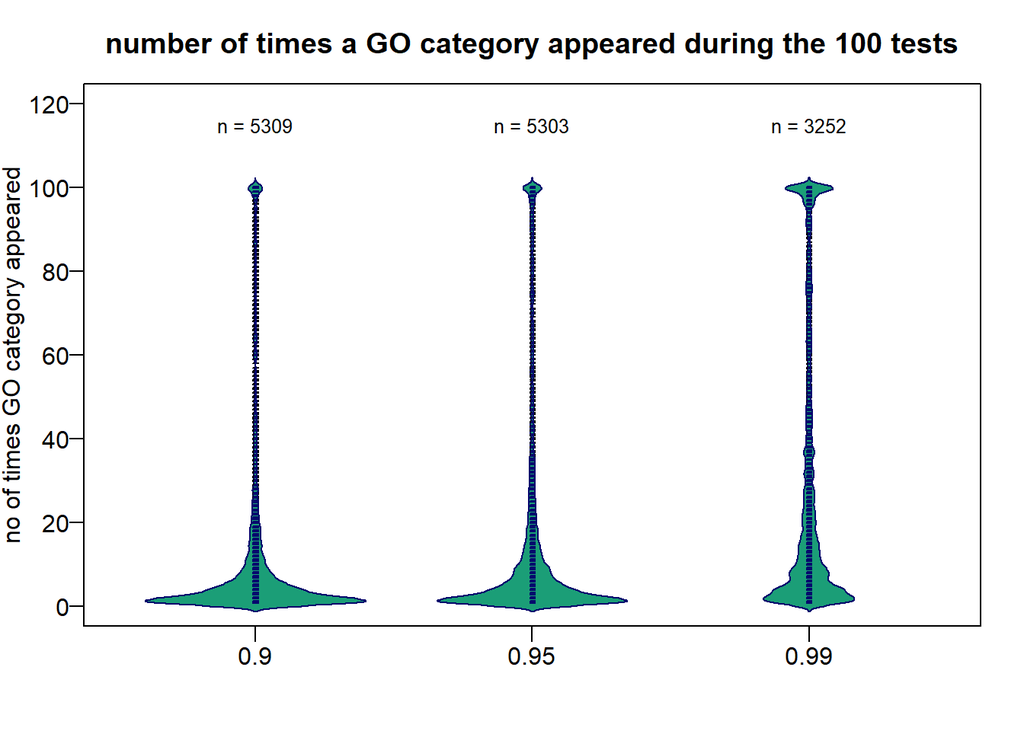

Replot just showing the data for categories that appeared >= 30 times

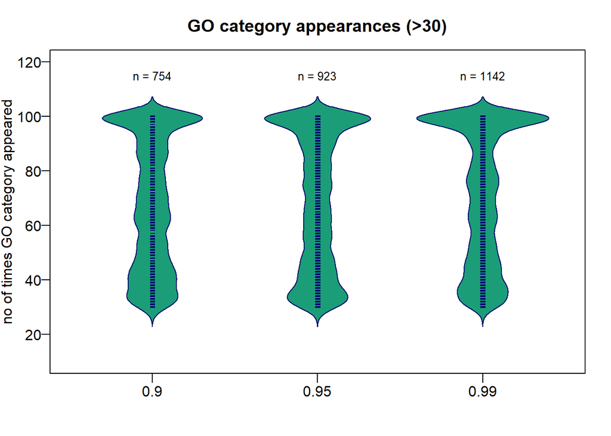

Now we could do with some stats to pick a cutoff for the number of times a category appears. Let’s just select an arbitrary value for now….

Create a dataset that contains these suspect set of categories

### Deduplicate

#### Number of overlapping functional terms between the thresholds

```
## [1] 795
```

```
## [1] 665
```

```
## [1] 727
```

There are 795 overlapping categories between 0.99 and 0.95.  
There are 665 overlapping categories between 0.99 and 0.9.  
There are 727 overlapping categories between 0.95 and 0.9.

The duplicate terms will be removed from the more stringent categories.

The number of terms remaining after deduplication

```
##  0.9 0.95 0.99
##  754  196  339
```

Rename the categories